# Final Project

## Prediction & Forecasting the stock market price of Microsoft with LSTM

## Section 1: Introduction

The primary objective of this analysis is to predict the stock market price of Microsoft using deep learning methods. Leveraging historical stock market data from March 13, 1986, to December 29, 2023, the aim is to develop a robust predictive model that assists in forecasting Microsoft's stock prices.

```python
# Importing necessary library
import pandas as pd

# Reading the dataset 'MSFT.csv' into a DataFrame
df = pd.read_csv('MSFT.csv')  # 'MSFT.csv' file contains the historical data of Microsoft stock prices.
df
```

|  | Date | Open | High | Low | Close | Adj Close | Volume |
| --- | --- | --- | --- | --- | --- | --- | --- |
| 0 | 1986-03-13 | 0.088542 | 0.101563 | 0.088542 | 0.097222 | 0.060274 | 1031788800 |
| 1 | 1986-03-14 | 0.097222 | 0.102431 | 0.097222 | 0.100694 | 0.062427 | 308160000 |
| 2 | 1986-03-17 | 0.100694 | 0.103299 | 0.100694 | 0.102431 | 0.063504 | 133171200 |
| 3 | 1986-03-18 | 0.102431 | 0.103299 | 0.098958 | 0.099826 | 0.061889 | 67766400 |
| 4 | 1986-03-19 | 0.099826 | 0.100694 | 0.097222 | 0.098090 | 0.060812 | 47894400 |
| ... | ... | ... | ... | ... | ... | ... | ... |
| 9522 | 2023-12-22 | 373.679993 | 375.179993 | 372.709991 | 374.579987 | 374.579987 | 17091100 |
| 9523 | 2023-12-26 | 375.000000 | 376.940002 | 373.500000 | 374.660004 | 374.660004 | 12673100 |
| 9524 | 2023-12-27 | 373.690002 | 375.059998 | 372.809998 | 374.070007 | 374.070007 | 14905400 |
| 9525 | 2023-12-28 | 375.369995 | 376.459991 | 374.160004 | 375.279999 | 375.279999 | 14327000 |
| 9526 | 2023-12-29 | 376.000000 | 377.160004 | 373.480011 | 376.040009 | 376.040009 | 18723000 |

9527 rows × 7 columns

## Section 2: Data Exploration

### Data Overview

The initial exploration involved loading the dataset, containing attributes such as 'Date,' 'Open,' 'High,' 'Low,' 'Close,' 'Adjusted Close,' and 'Volume.' Subsequently, the DataFrame was refined to retain only the 'Date' and 'Close' columns, essential for modeling purposes.

```python
# Subsetting the DataFrame to retain only the 'Date' and 'Close' columns
df = df[['Date','Close']]
df
```

|  | Date | Close |
| --- | --- | --- |
| 0 | 1986-03-13 | 0.097222 |
| 1 | 1986-03-14 | 0.100694 |
| 2 | 1986-03-17 | 0.102431 |
| 3 | 1986-03-18 | 0.099826 |
| 4 | 1986-03-19 | 0.098090 |
| ... | ... | ... |
| 9522 | 2023-12-22 | 374.579987 |
| 9523 | 2023-12-26 | 374.660004 |
| 9524 | 2023-12-27 | 374.070007 |
| 9525 | 2023-12-28 | 375.279999 |
| 9526 | 2023-12-29 | 376.040009 |

9527 rows × 2 columns

### Date Type Conversion

Data Type Conversion for 'Date' Column , The provided code segment aims to convert the 'Date' column, initially of type 'object', into a datetime type for enhanced temporal analysis.

- The code initializes a function str_to_datetime that accepts a date string in 'YYYY-MM-DD' format and converts it into a datetime object.
- str_to_datetime uses the datetime.datetime constructor to create a datetime object from the split year, month, and day values of the input string.
- An example conversion is demonstrated for the date '1986-03-13' to showcase the conversion process.

```python
# Displaying the 'Date' column from the DataFrame
df['Date']
```

```
0       1986-03-13
1       1986-03-14
2       1986-03-17
3       1986-03-18
4       1986-03-19
           ...
9522    2023-12-22
9523    2023-12-26
9524    2023-12-27
9525    2023-12-28
9526    2023-12-29
Name: Date, Length: 9527, dtype: object
```

```python
import datetime

def str_to_datetime(s):
    split = s.split('-')   # Splitting the date string by hyphens to extract year, month, and day
    year,month,day = int(split[0]),int(split[1]),int(split[2])  # Converting split parts into integers
    return datetime.datetime(year=year, month=month, day=day)   # Creating a datetime object

datetime_object = str_to_datetime('1986-03-13')  # Example: Converting a date string to datetime
datetime_object
```

```
datetime.datetime(1986, 3, 13, 0, 0)
```

```python
# Applying the str_to_datetime function to convert 'Date' column to datetime objects
df['Date'] = df['Date'].apply(str_to_datetime)

# Displaying the updated 'Date' column after conversion
df['Date']
```

```
0      1986-03-13
1      1986-03-14
2      1986-03-17
3      1986-03-18
4      1986-03-19
          ...
9522   2023-12-22
9523   2023-12-26
9524   2023-12-27
9525   2023-12-28
9526   2023-12-29
Name: Date, Length: 9527, dtype: datetime64[ns]
```

```python
# Setting the DataFrame index to the 'Date' column and popping 'Date' from the DataFrame columns
df.index = df.pop('Date')

# Displaying the modified DataFrame with 'Date' column as the index
df
```

| Date | Close |
| --- | --- |
| 1986-03-13 | 0.097222 |
| 1986-03-14 | 0.100694 |
| 1986-03-17 | 0.102431 |
| 1986-03-18 | 0.099826 |
| 1986-03-19 | 0.098090 |
| ... | ... |
| 2023-12-22 | 374.579987 |
| 2023-12-26 | 374.660004 |
| 2023-12-27 | 374.070007 |
| 2023-12-28 | 375.279999 |
| 2023-12-29 | 376.040009 |

9527 rows × 1 columns

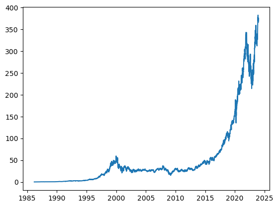

```python
import matplotlib.pyplot as plt

# Plotting the 'Close' values against the DataFrame index
plt.plot(df.index, df['Close'])
```

## Section 3: Data Preparation for Modeling

### Windowed DataFrame Generation

This section involves the creation of a windowed DataFrame, leveraging the function df_to_windowed_df, to structure the existing dataset for analysis. The generated windowed DataFrame aims to organize data into specific windows, setting the groundwork for subsequent time-based analysis or modeling tasks.

#### Purpose:

- Windowed DataFrame Creation: Focuses on segmenting the original dataset into distinct windows, allowing for structured representation suitable for time series or sequential analysis.
- Data Transformation for Analysis: Following the windowed DataFrame creation, on transforming this structured data into organized components—dates, input features (X), and output values (y)—essential for predictive modeling tasks or time-based analysis.

#### Code Complexity and Development Effort:

- Code Complexity: Moderate-to-high due to date handling, DataFrame manipulation, and iterative processes involved.
- Development Effort: Significant time and effort invested in comprehending, developing, and refining code functionalities, requiring thorough investigation and testing.

#### Overview:

The combined sections involve the creation of a windowed DataFrame and its conversion into structured data components—dates, input features (X), and output values (y). This process significantly contributes to the preparation of data suitable for predictive modeling, emphasizing the importance of organized data for time series analysis and forecasting tasks.

```python
import numpy as np

# Convert date strings to datetime objects
def df_to_windowed_df(dataframe, first_date_str, last_date_str, n=3):
  first_date = str_to_datetime(first_date_str)
  last_date  = str_to_datetime(last_date_str)

  # Initialize variables to store dates, input features (X), and output values (Y)
  target_date = first_date

  dates = []
  X, Y = [], []

  last_time = False
  while True:
    df_subset = dataframe.loc[:target_date].tail(n+1)  ## Extract a subset of the DataFrame up to the target date

    # Check if the subset size matches the window size
    if len(df_subset) != n+1:
      print(f'Error: Window of size {n} is too large for date {target_date}')
      return

    # Extract input and output values from the subse
    values = df_subset['Close'].to_numpy()
    x, y = values[:-1], values[-1]

    # Store dates, input features, and output values
    dates.append(target_date)
    X.append(x)
    Y.append(y)

    # Determine the next week's date for iteration
    next_week = dataframe.loc[target_date:target_date+datetime.timedelta(days=7)]
    next_datetime_str = str(next_week.head(2).tail(1).index.values[0])
    next_date_str = next_datetime_str.split('T')[0]
    year_month_day = next_date_str.split('-')
    year, month, day = year_month_day
    next_date = datetime.datetime(day=int(day), month=int(month), year=int(year))

    # Check if the last date has been reached
    if last_time:
      break

    target_date = next_date

    if target_date == last_date:
      last_time = True

  # Create a new DataFrame to organize the collected data
  ret_df = pd.DataFrame({})
  ret_df['Target Date'] = dates

  X = np.array(X)
  for i in range(0, n):
    X[:, i]
    ret_df[f'Target-{n-i}'] = X[:, i]

  # Store output values in the new DataFrame
  ret_df['Target'] = Y

  return ret_df

# Generate a windowed DataFrame for the specified date range and window size
# Start day second time around: '2018-12-29'
windowed_df = df_to_windowed_df(df,
                                '2018-12-29',
                                '2023-12-29',
                                n=3)
windowed_df
```

|  | Target Date | Target-3 | Target-2 | Target-1 | Target |
| --- | --- | --- | --- | --- | --- |
| 0 | 2018-12-29 | 94.129997 | 100.559998 | 101.180000 | 100.389999 |
| 1 | 2019-01-02 | 101.180000 | 100.389999 | 101.570000 | 101.120003 |
| 2 | 2019-01-03 | 100.389999 | 101.570000 | 101.120003 | 97.400002 |
| 3 | 2019-01-04 | 101.570000 | 101.120003 | 97.400002 | 101.930000 |
| 4 | 2019-01-07 | 101.120003 | 97.400002 | 101.930000 | 102.059998 |
| ... | ... | ... | ... | ... | ... |
| 1254 | 2023-12-22 | 373.260010 | 370.619995 | 373.540009 | 374.579987 |
| 1255 | 2023-12-26 | 370.619995 | 373.540009 | 374.579987 | 374.660004 |
| 1256 | 2023-12-27 | 373.540009 | 374.579987 | 374.660004 | 374.070007 |
| 1257 | 2023-12-28 | 374.579987 | 374.660004 | 374.070007 | 375.279999 |
| 1258 | 2023-12-29 | 374.660004 | 374.070007 | 375.279999 | 376.040009 |

1259 rows × 5 columns

```python
def windowed_df_to_date_X_y(windowed_dataframe):
  # Convert windowed DataFrame to a NumPy array
  df_as_np = windowed_dataframe.to_numpy()

  # Extract dates, input features (X), and output values (Y) from the array
  dates = df_as_np[:, 0]

  # Extract input features, reshape into a 3D array for model input
  middle_matrix = df_as_np[:, 1:-1]
  X = middle_matrix.reshape((len(dates), middle_matrix.shape[1], 1))

  # Extract output values
  Y = df_as_np[:, -1]

  return dates, X.astype(np.float32), Y.astype(np.float32)

# Convert windowed DataFrame into structured dates, input features, and output values
dates, X, y = windowed_df_to_date_X_y(windowed_df)

# Display the shapes of the extracted dates, input features, and output values
dates.shape, X.shape, y.shape
```

```
((1259,), (1259, 3, 1), (1259,))
```

In this final part of this section, the code finalizes the dataset preparation by dividing it into distinct subsets: training, validation, and test sets. The dataset is segmented into these subsets based on defined proportions: 80% for training, 10% for validation, and 10% for testing. This partitioning is vital for evaluating the model's performance on unseen data after training and validation. The code then uses Matplotlib to create a visual representation, plotting each set—training, validation, and test—across time, enabling a clear comparison between these partitions. This step ensures that the model is trained on a substantial portion of the data, validated on a separate portion, and ultimately tested on completely unseen data to gauge its real-world predictive capacity.

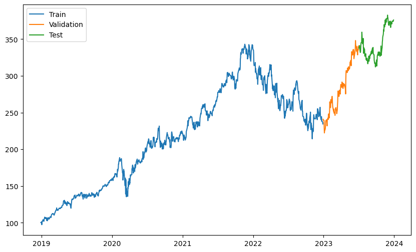

```python
# Splitting dataset into training, validation, and test sets
q_80 = int(len(dates) * .8)  # Index for 80% of the dataset
q_90 = int(len(dates) * .9)  # Index for 90% of the dataset

dates_train, X_train, y_train = dates[:q_80], X[:q_80], y[:q_80]  # Training set

dates_val, X_val, y_val = dates[q_80:q_90], X[q_80:q_90], y[q_80:q_90]  # Validation set
dates_test, X_test, y_test = dates[q_90:], X[q_90:], y[q_90:]      # Test set

# Plotting the subsets
plt.figure(figsize=(10,6))
plt.plot(dates_train, y_train)
plt.plot(dates_val, y_val)
plt.plot(dates_test, y_test)

plt.legend(['Train', 'Validation', 'Test'])
```

## Section 4 : Section 4: LSTM Model Building

#### Overview:

This section focuses on the construction and evaluation of a Long Short-Term Memory (LSTM) model using TensorFlow and Keras. The LSTM architecture is a type of recurrent neural network (RNN) known for its ability to process sequences of data and capture long-term dependencies within the data.

### Purpose:

- Model Construction: The code segment initiates the construction of the LSTM model using TensorFlow and Keras. The model consists of an input layer, LSTM layer, and several densely connected layers.
- Model Compilation: It compiles the model with mean squared error (MSE) as the loss function and the Adam optimizer with a specific learning rate.
- Model Training: The model is trained on the training set (X_train, y_train) for a specified number of epochs, and its performance is evaluated on the validation set (X_val, y_val).
- Prediction Visualization: Subsequent code segments generate visualizations showcasing the model's predictions against the observed values for the validation and test datasets, providing insights into the model's performance.
- Recursive Predictions: Another part of the code generates recursive predictions where the model forecasts the next value based on its previous prediction, iterating over the validation and test sets.

### Methodology:

- Model Architecture: Sequential model with an LSTM layer followed by densely connected layers with ReLU activation.
- Model Training: Trained using the training data with a defined optimizer and loss function.
- Prediction Evaluation: Compares model predictions with observed values for validation and test datasets, assessing model performance.
- Recursive Forecasting: Generates predictions recursively, where each prediction feeds into the model for the next prediction iteration.

This methodology aims to showcase the LSTM model's ability to forecast time series data and assess its performance against different subsets of the dataset.

```python
from tensorflow.keras.models import Sequential
from tensorflow.keras.optimizers import Adam
from tensorflow.keras import layers

# Create a sequential model
model = Sequential([layers.Input((3, 1)),    # Input layer with shape (3, 1)
                    layers.LSTM(64),          # LSTM layer with 64 units
                    layers.Dense(32, activation='relu'),   # Dense layer with 32 units and ReLU activation
                    layers.Dense(32, activation='relu'),   # Another dense layer with 32 units and ReLU activation
                    layers.Dense(1)])               # Output layer with single unit

# Compile the model with mean squared error loss, Adam optimizer with a specific learning rate,
# and mean absolute error as a metric
model.compile(loss='mse',
              optimizer=Adam(learning_rate=0.001),
              metrics=['mean_absolute_error'])

# Train the model on the training set (X_train, y_train) using validation data (X_val, y_val) for 100 epochs
model.fit(X_train, y_train, validation_data=(X_val, y_val), epochs=100)
```

```
<keras.src.callbacks.History at 0x2db1bbdc250>
```

### Visualization of Training Data Predictions

The provided code below segment is responsible for generating a visual comparison between the predictions made by a machine learning model and the actual observations within the training dataset. This visualization aims to offer insights into the model's performance on the training data.

- Training Predictions Line: This line represents the values predicted by the machine learning model for the training dataset. Each point on this line indicates the model's prediction for a specific instance within the training data.
- Training Observations Line: This line illustrates the actual observed values from the training dataset. It represents the real data points or ground truth values.

ideally, the two lines should align closely or overlap each other. A close fit between the 'Training Predictions' and 'Training Observations' lines signifies that the model has learned well from the training data. If there's a significant deviation or gap between these lines, it might indicate:

1. Model Accuracy: A close alignment between the lines indicates that the model has learned to predict the training data accurately.
2. Overfitting or Underfitting:
- Overfitting: If the 'Training Predictions' line closely follows the training data but deviates significantly from the 'Training Observations' line, it could indicate the model has overfit the training data, capturing noise or specific patterns that don't generalize well.
- Underfitting: A large gap between both lines suggests the model hasn't captured the underlying patterns in the training data adequately.
3. Prediction Errors: Differences between the lines could also indicate areas where the model struggles to make accurate predictions, pointing to instances where the model requires improvement or where the data might be inherently noisy or complex.

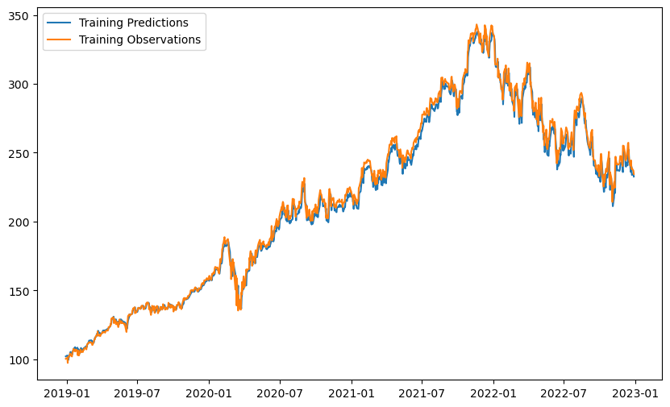

```python
train_predictions = model.predict(X_train).flatten()

plt.figure(figsize=(10, 6))
plt.plot(dates_train, train_predictions)
plt.plot(dates_train, y_train)
plt.legend(['Training Predictions', 'Training Observations'])
```

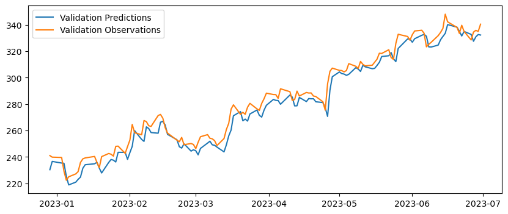

```python
val_predictions = model.predict(X_val).flatten()

plt.figure(figsize=(10,4))
plt.plot(dates_val, val_predictions)
plt.plot(dates_val, y_val)
plt.legend(['Validation Predictions', 'Validation Observations'])
```

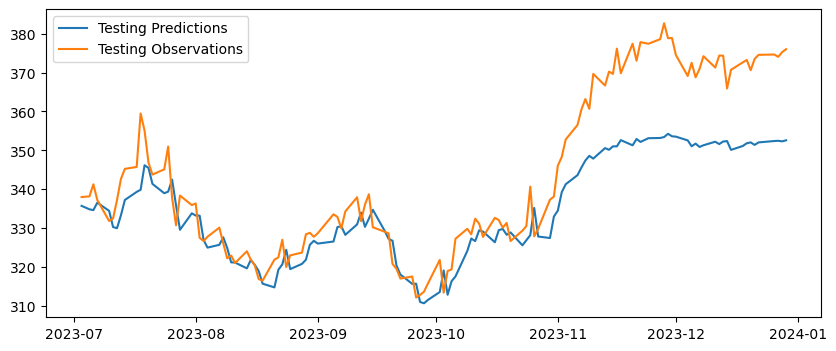

```python
test_predictions = model.predict(X_test).flatten()

plt.figure(figsize=(10,4))
plt.plot(dates_test, test_predictions)
plt.plot(dates_test, y_test)
plt.legend(['Testing Predictions', 'Testing Observations'])
```

##### By plotting these six lines together, this visualization allows for a holistic view of how well the model performs across different datasets:

- Model Performance Assessment: Comparing predictions with actual observations across all datasets.
- Generalization Check: Analyzing if the model's performance remains consistent across unseen data (validation and testing datasets).
- Overfitting/Underfitting Evaluation: Observing potential disparities between predictions and observations across datasets.

The legend provided corresponds to each line in the graph, enabling clear identification of which line represents which dataset's predictions and observations.

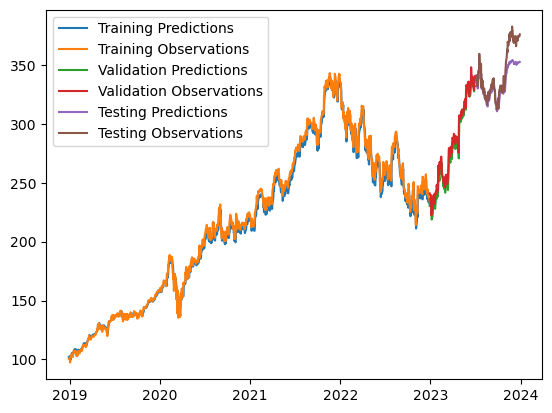

```python
plt.plot(dates_train, train_predictions)
plt.plot(dates_train, y_train)
plt.plot(dates_val, val_predictions)
plt.plot(dates_val, y_val)
plt.plot(dates_test, test_predictions)
plt.plot(dates_test, y_test)
plt.legend(['Training Predictions',
            'Training Observations',
            'Validation Predictions',
            'Validation Observations',
            'Testing Predictions',
            'Testing Observations'])
```

However, it's important to handle the recursive predictions with care, as errors might accumulate over each step, potentially affecting the accuracy of long-term predictions. Evaluation and validation on such recursive predictions are crucial to assess the model's performance in this scenario.

```python
from copy import deepcopy

recursive_predictions = []  # Initialize an empty list to store the predicted values
recursive_dates = np.concatenate([dates_val, dates_test]) # Concatenate validation and test dates to create a combined date sequence

# Iterate through each date in the combined validation and test set
for target_date in recursive_dates:
  last_window = deepcopy(X_train[-1])     # Create a copy of the last window in the training data
  next_prediction = model.predict(np.array([last_window])).flatten()      # Predict the next value based on the last window and flatten the result
  recursive_predictions.append(next_prediction)     # Append the predicted value to the list of recursive predictions
  last_window[-1] = next_prediction       # Update the last element in the window with the predicted value for the next iteration
```

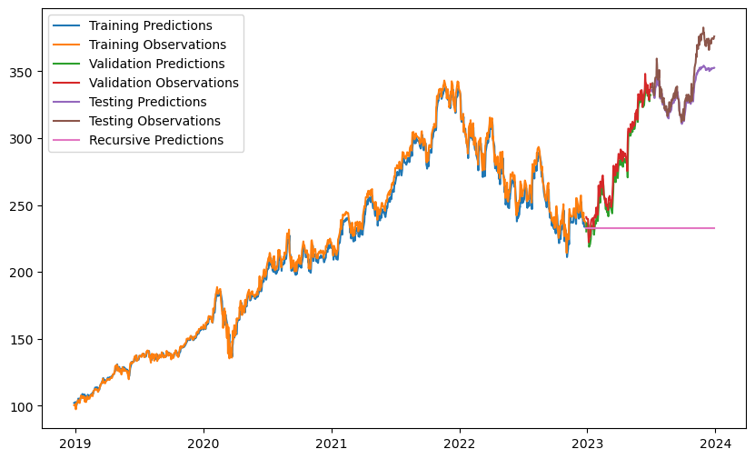

```python
plt.figure(figsize=(10,6))
plt.plot(dates_train, train_predictions)
plt.plot(dates_train, y_train)
plt.plot(dates_val, val_predictions)
plt.plot(dates_val, y_val)
plt.plot(dates_test, test_predictions)
plt.plot(dates_test, y_test)
plt.plot(recursive_dates, recursive_predictions)
plt.legend(['Training Predictions',
            'Training Observations',
            'Validation Predictions',
            'Validation Observations',
            'Testing Predictions',
            'Testing Observations',
            'Recursive Predictions'])
```